# TP PRICE PREDICTION GROUPE 06

# 6. EVALUONS LES DIFFERENTES METRIC DE REGRESSION D'UN MODELE

```python
print('Train de prediction\n')
y_pred = rfr_optimize.predict(X_train)

# 1. Median Absolute Error (MedAE)
medae = median_absolute_error(y_train, y_pred)


# 2. Trimmed Mean Absolute Error (TMAE)
trim = 0.1  # Trim 10% of outliers from both ends
# I remove outliers with too low values and those with too high values
sorted_errors = np.sort(np.abs(y_train - y_pred))
trim_size = int(trim * len(sorted_errors))
trimmed_errors = sorted_errors[trim_size:-trim_size]
tmae = np.mean(trimmed_errors)


# 3. Coefficient de détermination (R²)
r_squared = r2_score(y_train, y_pred)


# 4. Mean Absolute Error (MAE)
mae = mean_absolute_error(y_train, y_pred)

#5. Root Mean Squared Error(RMSE)
rmse = (np.sqrt(mean_squared_error(y_train,y_pred)))



# Print the computed metrics
print(f"Median Absolute Error (MedAE):        {round(medae,2)}" )
print(f"Trimmed Mean Absolute Error (TMAE):   {round(tmae,2)}")
print(f"Coefficient de détermination (R²):    {round(r_squared,2) *100}%")
print(f"Mean Absolute Error (MAE):            {round(mae,2)}")
print(f"Root Mean Absolute Error (RMSE):      {round(rmse,2)}")
```

```
Train de prediction

Median Absolute Error (MedAE):        1.22
Trimmed Mean Absolute Error (TMAE):   1.37
Coefficient de détermination (R²):    93.0%
Mean Absolute Error (MAE):            1.64
Root Mean Absolute Error (RMSE):      2.35
```

```python
print('Test de prediction\n')
y_pred = rfr_optimize.predict(X_test)

# 1. Median Absolute Error (MedAE)
medae = median_absolute_error(y_test, y_pred)


# 2. Trimmed Mean Absolute Error (TMAE)
trim = 0.1  # Trim 10% of outliers from both ends
# I remove outliers with too low values and those with too high values
sorted_errors = np.sort(np.abs(y_test - y_pred))
trim_size = int(trim * len(sorted_errors))
trimmed_errors = sorted_errors[trim_size:-trim_size]
tmae = np.mean(trimmed_errors)


# 3. Coefficient de détermination (R²)
r_squared = r2_score(y_test, y_pred)


# 4. Mean Absolute Error (MAE)
mae = mean_absolute_error(y_test, y_pred)

#5. Root Mean Squared Error(RMSE)
rmse = (np.sqrt(mean_squared_error(y_test,y_pred)))




# Print the computed metrics
print(f"Median Absolute Error (MedAE):        {round(medae,2)}" )
print(f"Trimmed Mean Absolute Error (TMAE):   {round(tmae,2)}")
print(f"Coefficient de détermination (R²):    {round(r_squared,2) *100}%")
print(f"Mean Absolute Error (MAE):            {round(mae,2)}")
print(f"Root Mean Absolute Error (RMSE):      {round(rmse,2)}")
```

```
Test de prediction

Median Absolute Error (MedAE):        1.5
Trimmed Mean Absolute Error (TMAE):   2.07
Coefficient de détermination (R²):    77.0%
Mean Absolute Error (MAE):            2.77
Root Mean Absolute Error (RMSE):      4.42
```

### Les résultats que nous obtenons ici pour c'est différent métric choisis sont acceptable et aussi aucune metric ne ma donner un score trop proche de zéro sinon overfitting...

### Car la différence entre les

#### MedAE est de 0.28 TMAE 0.7 R2_score 16% RMSE 2.07

# 7. PLUS DE DONNEES NOUS GARANTIE UN MEILLEUR MODELE ??

```python
# Nous allons utiliser la fonction learning curve pour les savoir
N, train_score,val_score = learning_curve(rfr_optimize,
                                          X_train,
                                          y_train,
                                          train_sizes=np.linspace(0.1,1.0,10),
                                          cv=5
                                         )
```

```python
print('Differente taille des X_train :',N)
```

```
Differente taille des X_train : [ 32  64  96 129 161 193 226 258 290 323]
```

```python
print('Score moyen des différent entrainement respective:',train_score.mean())
```

```
Score moyen des différent entrainement respective: 0.9360840880200567
```

```python
print('Validation Score moyen des différent entrainement respective:',val_score.mean())
```

```
Validation Score moyen des différent entrainement respective: 0.8034248698228516
```

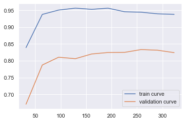

```python
plt.plot(N,train_score.mean(axis=1),label='train curve')
plt.plot(N,val_score.mean(axis=1), label='validation curve')
plt.legend()
plt.show()
```

### "Pour savoir si davantage de données amélioreront le modèle, il faut que les deux courbes ci-dessus se rejoignent ou se confondent à un moment donné.

### À ce moment-là, nous observons la valeur en abscisse, ce qui représentera le nombre de points (d'observations / d'individus) pour lesquels le modèle aura de meilleures performances."

```python
def house_cost(rfr_optimize,PTRATIO,LSTAT,RM,RAD,CRIM):
    x = np.array([PTRATIO,LSTAT,RM,RAD,CRIM]).reshape(1,5)
    price = np.rint(rfr.predict(x))
    return price
```

```python
house_cost(rfr_optimize,21.0,10.26,6.096,4.0,0.63796)
```

```
array([19.])
```

# 8.SERIALIZATION DU MODELE

```python
# Sauvegarde du modele
joblib.dump(rfr_optimize,'RandomForestModel.joblib')
```

```
['RandomForestModel.joblib']
```

```python
#Importation du modèle
model = joblib.load('RandomForestModel.joblib')
```

```python
#Prediction en utilisant ce modele
#x = np.array([PTRATIO,LSTAT,RM,RAD,CRIM]).reshape(1,5)

var=np.array(['15.2','4.56','6.556','5.0','0.12579']).reshape(1,5)
prediction = model.predict(var)
```

```python
prediction
```

```
array([29.28430402])
```

# TP PRICE PREDICTION GROUPE 06